# Thinking Historically about Music

Andrew Cashner, PhD

Tu 2022/01/18, MUSC222 Week 1–2

# Check-in about class structure, policies, assignments

# What does your map of the musical world look like?

[figure not shown]

16th-century world map

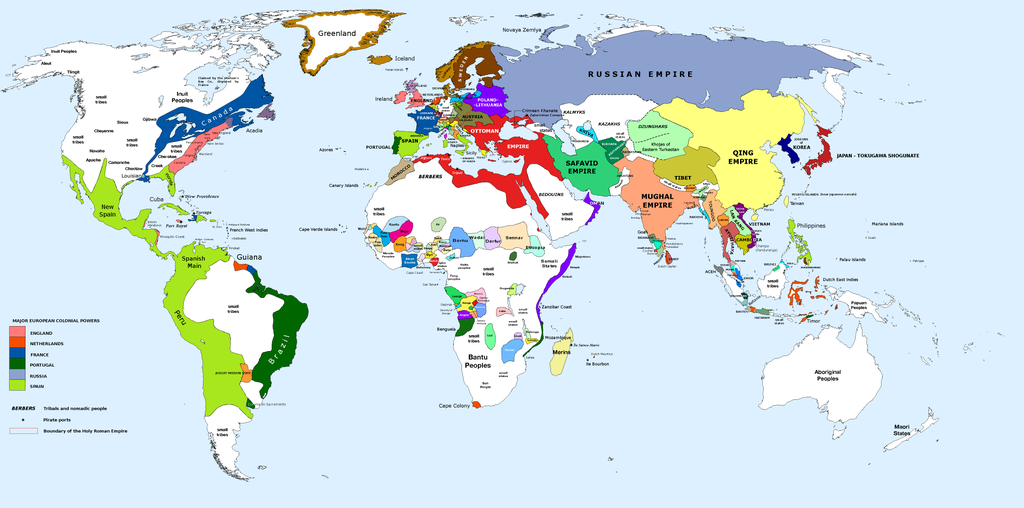

Political map of the world c. 1700

# I. Sonic and social elements of music

## Sonic (how does it sound?)

1. Rhythm
2. Melody
3. Harmony
4. Texture
5. Color

## Social (who does it and why?)

1. Performer
2. Composer
3. Audience
4. Patron
5. Venue
6. Medium

## Mixed

1. Genre
2. Canon

# Sonic Elements (detail)

1. Rhythm
   - How is time structured in patterns of stress, movement?
   - What would you tap or dance along with?
2. Melody
   - How is pitch structured in the most prominent way?
   - What is the principal idea that you could sing along with?
3. Harmony
   - How are multiple pitches (voices or chords) combined?
4. Texture
   - How are different layers of music combined and what is the relationship between them?
   - E.g., monophony, polyphony, heterophony, melody-and-accompaniment (distinct from “homophony”); groove-based musics
5. Color
   - What timbres, tones, instruments, “overtone signatures” are used?

# Social Elements

1. Performer
   - Who makes the music sound?
2. Composer
   - Who thinks up the musical ideas?
3. Audience
   - Who hears (participates in) the music?
   - What do they do with it? What do they expect it to do for them?
4. Patron
   - Who pays for the music?
5. Venue
   - Where is the music presented?
6. Medium
   - How does the music get from one person to another?

# Mixed Elements

1. Genre
   - What do people expect to hear from this kind of music?
   - “generic contract” between creator and audience
   - style + social function = genre
2. Canon
   - How do people understand this music to be connected to other music as part of a tradition?
   - How do people assign value to this music?

# II. Thinking historically about music

- What does it mean to study music historically?
- What music should we study?
- How should we study it?

## Four examples of music from the 17-18C or older

1. G. F. Handel, *Messiah*: “Hallelujah”
2. African-American spiritual, *Glory, Glory, Hallelujah*
3. Akwesasne Water Song
4. “Píng Yùn Chuàn” (平韵串) (“A String of Serene Harmonies”), from the collection “Qīng gù gōng wángfǔ yīnyuè” (清故恭王府音乐)

# Handel’s *Messiah*

G. F. Handel, *Messiah*: “Hallelujah”

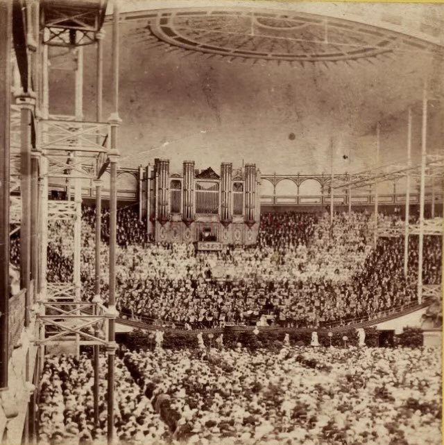

1857 performance in Crystal Palace, London

# African-American spiritual, *Glory, Glory, Hallelujah*

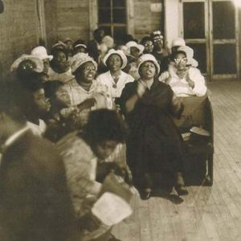

African-American church singers

Glory, glory, hallelujah!  
Since I laid my burdens down.  
Glory, glory, hallelujah!  
Since I laid my burdens down!  
I feel better, so much better  
Since I laid my burdens down.  
I feel better, so much better  
Since I laid my burdens down!  
I’m goin’ home to be with Jesus  
Since I laid my burdens down.  
I’m goin’ home to be with Jesus  
Since I laid my burdens down!

# Akwesasne Water Song

- Traditional social song of the Akwesasne (Mohawk) nation
- One of the Six Nations of the Haudenosaunee (Iroquois) Confederacy in New York state region

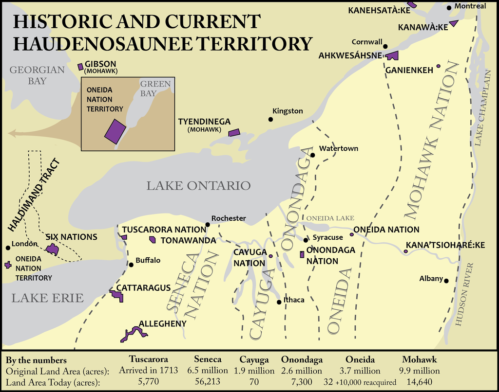

Haudenosaunee lands

# “Píng Yùn Chuàn” (平韵串)

[figure not shown]

Sanxian player

- China, Qing dynasty (大淸) (1644–1912)
- From the collection “Qīng gù gōng wángfǔ yīnyuè” (清故恭王府音乐)
- *Sānxián* (三弦) music learned by Tan Longjian (谈龙建, b. 1952) from Àixīnjuéluó Yùhuán (爱新觉罗·毓峘, 1929–2003)
  - [Sanxian at the Met museum](https://www.metmuseum.org/art/collection/search/505692)

# III. Four style worlds in European music 1600–1800

1. “Renaissance”, *stile antico* (16C)
2. “Early Baroque”, *stile concertato* (17C)
3. “High Baroque” (17–18C)
4. “Viennese Classic”, galant (18C)

## Examples

1. Vicente Lusitano, *Inviolata, integra et casta es*
2. Chiara Maria Cozzolani, *O Jesu meus amor*
3. Antonio Vivaldi, *Nulla in mundo pax sincero*: Mvt. I
4. Wolfgang Amadé Mozart, “Coronation” Mass: Agnus Dei

# Closing question

- What do you think should be included on a map of “Western Music 1600–1800” and why?

[figure not shown]

1641 world map